```python
import numpy as np
import pandas as pd
import matplotlib as mat
import matplotlib.pyplot as plt
import seaborn as sns
from PIL import Image
%matplotlib inline
from scipy import stats
from datetime import date
```

# 1(A): find the joint probability of the people who planned to purchase and actually placed an order.

P(A)= probability of people planned to purchase product A P(B)= probability of people actually placed order for product A n(A)= people who planned to purchase product A= 500 n(B)= people who actually placed oreder for product A= 600 total no. of events= 2000 A intersection B= 400 so the joint probabilty pJ = n(A intersection B)/total no. of events

```python
FE= 400    #favorable events
TE= 2000   #total no. of events
PJ= round(FE / TE, 4)  # joint probabilty as mentioned in question 1
print('1.A.joint probability of the people who planned to purchase and actually placed an order. is %1.4f' % PJ)
```

```
1.A.joint probability of the people who planned to purchase and actually placed an order. is 0.2000
```

# 1.B.joint probility of the people who planned to purchase and actually placed an order, given that peole planned to purchase

PJ2= P(B)*P(B/A), where P(B/A)= conditional probability of B, given the fact A alreadt happend

```python
FE1= 600 # favourbale ways for B event
TE1= 2000# total no. of ways
pb= round(FE1/TE1, 4) # probabilty of people actually placed order for product A
print ('pb is %1.4lf\n'% pb)
```

```
pb is 0.3000
```

```python
FE2= 200 #
TE2= 1600
pc= round(FE2/TE2,4)# conditional probabilty of B, givan the fact A already happened
print('pc is %1.4f'%pc)
```

```
pc is 0.1250
```

```python
pd = round(pb*pc,4) # joint probility of the people who planned to purchase and actually placed an order, given that peole planned to purchase
print('1.B.joint probility of the people who planned to purchase and actually placed an order, given that peole\n\
planned to purchase. is %1.4f'%pd)
```

```
1.B.joint probility of the people who planned to purchase and actually placed an order, given that peole
planned to purchase. is 0.0375
```

Question no.2. An electrical manufacturing company conducts quality checks at specified periods on the products it manufactures. Historically, the failure rate for the manufactured item is 5%. Suppose a random sample of 10 manufactured items is selected. Answer the following questions. [4 Marks] 2.A. Probability that none of the items are defective? [1 Mark] 2.B. Probability that exactly one of the items is defective? [1 Mark] 2.C. Probability that two or fewer of the items are defective? [1 Mark] 2.D. Probability that three or more of the items are defective ? [1 Mark]

```python
n=10 # random samples of 10 items
p= 0.05 # percentage failure rate for manufacture items
k= np.arange(0,11)
binomial= stats.binom.pmf(k,n,p)
print (binomial)
```

```
[5.98736939e-01 3.15124705e-01 7.46347985e-02 1.04750594e-02
 9.64808106e-04 6.09352488e-05 2.67259863e-06 8.03789062e-08
 1.58642578e-09 1.85546875e-11 9.76562500e-14]
```

```python
#2.A. Probability that none of the items are defective?
print('2.A. Probability that none of the items are defective is %1.4f'%binomial[0])
```

```
2.A. Probability that none of the items are defective is 0.5987
```

```python
#2.B. Probability that exactly one of the items is defective?
print('2.B. Probability that exactly one of the items is defective is %1.4f'%binomial[1])
```

```
2.B. Probability that exactly one of the items is defective is 0.3151
```

```python
cumbinomial= stats.binom.cdf(k,n,p)
print(cumbinomial)
```

```
[0.59873694 0.91386164 0.98849644 0.9989715  0.99993631 0.99999725
 0.99999992 1.         1.         1.         1.        ]
```

```python
#2.C. Probability that two or fewer of the items are defective?
print('2.C.Probability that two or fewer of the items are defective is %1.4f'%cumbinomial[2])
```

```
2.C.Probability that two or fewer of the items are defective is 0.9885
```

```python
#2.D. Probability that three or more of the items are defective ?
P= 1-cumbinomial[2] #Probability that three or more of the items are defective
print('2.D.Probability that three or more of the items are defective is %1.4f'%P)
```

```
2.D.Probability that three or more of the items are defective is 0.0115
```

3. A car salesman sells on an average 3 cars per week. [3 Marks] 3.A. What is Probability that in a given week he will sell some cars? [1 Mark] 3.B. What is Probability that in a given week he will sell 2 or more but less than 5 cars? [1 Mark] 3.C. Plot the poisson distribution function for cumulative probability of cars sold per-week vs number of cars sold per week. [1 Mark] here mean= 3

```python
rate = 3 # which is the mean
n= np.arange(0,20)
poisson= stats.poisson.pmf(n,rate)
print(poisson)
```

```
[4.97870684e-02 1.49361205e-01 2.24041808e-01 2.24041808e-01
 1.68031356e-01 1.00818813e-01 5.04094067e-02 2.16040315e-02
 8.10151179e-03 2.70050393e-03 8.10151179e-04 2.20950322e-04
 5.52375804e-05 1.27471339e-05 2.73152870e-06 5.46305740e-07
 1.02432326e-07 1.80762929e-08 3.01271548e-09 4.75691918e-10]
```

```python
#3.A. What is Probability that in a given week he will sell some cars?
p= 1-poisson[0] # probabilty of he will sell soem cars
print('3.A. Probability that in a given week he will sell some cars is %1.4f'%p)
```

```
3.A. Probability that in a given week he will sell some cars is 0.9502
```

```python
cumpoisson= stats.poisson.cdf(n,rate)
print (cumpoisson)
```

```
[0.04978707 0.19914827 0.42319008 0.64723189 0.81526324 0.91608206
 0.96649146 0.9880955  0.99619701 0.99889751 0.99970766 0.99992861
 0.99998385 0.9999966  0.99999933 0.99999988 0.99999998 1.
 1.         1.        ]
```

```python
p1= cumpoisson[2] # at least selling the two cars a week
p2= cumpoisson [4] # selling the less than 4 cars a week
print(p1,p2)
```

```
0.42319008112684364 0.8152632445237722
```

```python
#3.B. What is Probability that in a given week he will sell 2 or more but less than 5 cars?
p3 = p2-p1
print ('3.B. Probability that in a given week he will sell 2 or more but less than 5 cars is %1.4f'%p3)
```

```
3.B. Probability that in a given week he will sell 2 or more but less than 5 cars is 0.3921
```

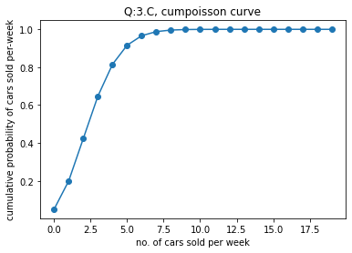

```python
#3.C. Plot the poisson distribution function for cumulative probability of cars sold per-week vs number of cars sold per week.
plt.plot(n,cumpoisson,'o-')
plt.title('Q:3.C, cumpoisson curve')
plt.xlabel('no. of cars sold per week')
plt.ylabel('cumulative probability of cars sold per-week')
plt.show()
```

4. Accuracy in understanding orders for a speech based bot at a restaurant is important for the Company X which has designed, marketed and launched the product for a contactless delivery due to the COVID-19 pandemic. Recognition accuracy that measures the percentage of orders that are taken correctly is 86.8%. Suppose that you place an order with the bot and two friends of yours independently place orders with the same bot. Answer the following questions. [3 Marks] 4.A. What is the probability that all three orders will be recognised correctly? [1 Mark] 4.B. What is the probability that none of the three orders will be recognised correctly? [1 Mark] 4.C. What is the probability that at least two of the three orders will be recognised correctly? [1 Mark]

```python
# from question
p4= 0.868 # percentage of orders that are taken correctly
n4=3
k4= np.arange(0,4)
```

```python
binomial1= stats.binom.pmf(k4,n4,p4)
print(binomial1)
```

```
[0.00229997 0.0453721  0.2983559  0.65397203]
```

```python
#4.A. What is the probability that all three orders will be recognised correctly?
print('4.A. the probability that all three orders will be recognised correctly is %1.4f'%binomial1[3])
```

```
4.A. the probability that all three orders will be recognised correctly is 0.6540
```

```python
#4.B. What is the probability that none of the three orders will be recognised correctly?
print('4.B. the probability that none of the three orders will be recognised correctly is %1.4f'%binomial1[0])
```

```
4.B. the probability that none of the three orders will be recognised correctly is 0.0023
```

```python
cumbinomial1= stats.binom.cdf(k4,n4,p4)
print(cumbinomial1)
```

```
[0.00229997 0.04767206 0.34602797 1.        ]
```

```python
#4.C. What is the probability that at least two of the three orders will be recognised correctly?
Pc= 1-cumbinomial1[1] #  probability that at least two of the three orders will be recognised correctly
print('the probability that at least two of the three orders will be recognised correctly is %1.4f'%Pc)
```

```
the probability that at least two of the three orders will be recognised correctly is 0.9523
```

5. Explain 1 real life industry scenario (other than the ones mentioned above) where you can use the concepts learnt in this module of Applied Statistics to get data driven business solution. [3 Marks] Ans.: lets take a look for material science research lab for energy storage devices, where a material scinetists tried to synthesized the varios material by taking base of 2D materials for battery applications in electric vehical. by applying these static methods we can draw a understaning which kind of material is good for battery in order to improvising the various factors of battery such as life cycle, energy density and power density. by doing all such studies, this statics saved time and resources of company. besides this, further this study can reveal the futur promising material for energy storage devices.